# Aside

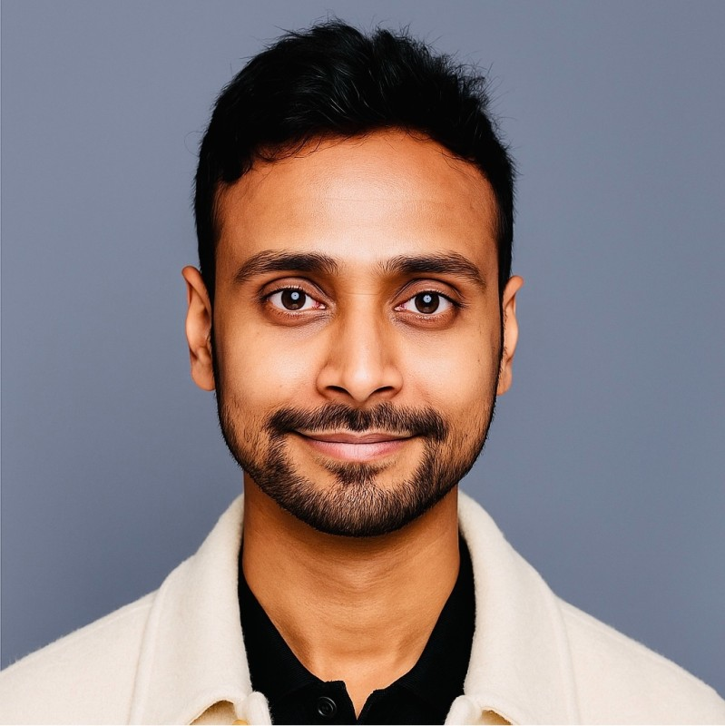

## Contact Info

- aditya.singh@gu.se
- github.com/addityea
- +46 793 539 123
- For more information, please contact me via email.

## Skills

- Single cell and spatial transcriptomics, pipeline dev, reproducibility
- Golang, R, Python, Nextflow/nf-core, Bash, CromWell/WDL
- Experience in HPC and cloud (GCP) cluster management and maintenance
- Molecular biology with a focus on CRISPR guided genome editing
- Experience in scientific writing and presentation

# Main

## Aditya Singh

### [NBIS](https://www.nbis.se), [University of Gothenburg](https://www.gu.se/en)

## Education

### Postgraduate Institute of Medical Education and Research, Paediatric Haematology Oncology

PhD in Medical Molecular biology

Chandigarh, India

2020 - 2016

Thesis: In-vitro BCR-ABL gene silencing in paediatric CML using CRISPR Cas system

### Punjabi University, Department of Microbiology

MSc in Microbiology

Patiala, India

2011 - 2009

Thesis: Cloning and overexpression of murA gene of Escherichia coli

### Panjab University, Department of Microbiology

BSc in Microbiology

Chandigarh, India

2009 - 2006

## Research Experience

### Bioinformatician

NBIS, University of Gothenburg, Core Facilities

Gothenburg, Sweden

Current - 2025/01

- Working with the National Bioinformatics Infrastructure Sweden (NBIS), stationed at GU
- Involved in cross-institutional projects around scRNAseq, spatial and multi-omics integration
- Providing teaching and trainings in the field of single cell, spatial transcriptomics and reproducibility
- Involved with ELIXIR Europe course on spatial science
- Nextflow and contributing to `nf-core` pipelines
- Containerization and serve deployment of courses: Docker, Pixi, Apptainer, Podman
- Part of NBIS Advisory program for PhD students
- Consulting science

### Postdoctoral Researcher

Karolinska Institutet, Clinical Neurosciences (Robert Harris Group)

Solna, Sweden

2024/12 - 2022/11

- ALS patient driven multi-omic data analysis (RNA-seq, scRNAseq, WGS) and gene regulatory network inference
- Integration of the multiome with patient pathophysiology and clinical data for disease dynamics interpretation using deep learning
- Development of individualized ALS patient disease dynamic models for improved clinical decision making
- Understanding the mammalian regeneration process using temporal differential gene expression analysis
- Supervision of ERASMUS master’s students
- Teaching bioinformatics to the students of the Master’s program at Karolinska Institutet

### Postdoctoral Researcher

Stanford Medicine, Department of Cardiology (Ashley Group)

Stanford, USA

2022/11 - 2021/01

- Designing of recombinant AAVs for improved cardiac tropism and immunogenic properties with a focus on hypertrophic cardiomyopathy
- Temporal multi-omics study of human performance and aging using RNA-seq, WGS, ATAC-seq and proteomics (MoTrPAC consortium)
- Development of Google cloud based platform for enabling the study

### Graduate Student

Postgraduate Institute of Medical Education and Research, Paeditric Haematology Oncology

Chandigarh, India

2020 - 2016

- Worked on knocking down the tumorigenicity of *BCR-ABL* chimeric gene in chronic myeloid leukemia cell line using CRISPR *Cas13a*
- Achieved a 4.5 times reduction in the downstream effects of the chimeric gene and 373x reduction in viability of the cancerous cells
- Developed novel diagnostics based on targeted next generation sequencing
- Bioinformatic platform development for clinical data handling
- Deep learning algorithms for accurately filtering true variant calls from next generation sequencing data.

## Select Publications

### Summary

Total Publications: 28

[ORCID](https://orcid.org/0000-0003-0827-7429)

Citations - ~150

h-index - 7

### Molecular adaptations in response to exercise training are associated with tissue-specific transcriptomic and epigenomic signatures

Cell Genomics

[DOI](https://doi.org/10.1016/j.xgen.2023.100421)

2024

Nair VD, Pincas H, Smith GR, Zaslavsky E, Ge Y, Amper MAS, Vasoya M, Chikina M, Sun Y, Raja AN, Mao W, Gay NR, Esser KA, Smith KS, Zhao B, Wiel L, **Singh A**, Lindholm ME, Amar D, Montgomery S, Snyder MP, Walsh MJ, Sealfon SC; MoTrPAC Study Group.

### Genetic architecture of cardiac dynamic flow volumes

Nature Genetics

[DOI](https://doi.org/10.1038/s41588-023-01587-5)

2023

Bruna Gomes, **Aditya Singh**, Jack W O’Sullivan, David Amar, Mykhailo Kostur, Francois Haddad, Michael Salerno, Victoria N. Parikh, Benjamin Meder, Euan A. Ashley

### Effective Downregulation of BCR-ABL Tumorigenicity by RNA Targeted CRISPR-*Cas13a*

Current Gene Therapy 2021;21(3):270-277

[DOI](https://doi.org/10.2174/1566523221666210217155233)

2021

**Aditya Singh**, Prateek Bhatia

### Comparative sequencing data analysis of Ion Torrent and MinION sequencing platforms using a clinical diagnostic haematology panel

Int J Lab Hem 42, 833– 841

[DOI](https://doi.org/10.1111/ijlh.13286)

2020

**Aditya Singh**, Prateek Bhatia

## Talks and conferences

### The cell autonomous effects on sporadic ALS onset and survival

ENCALS Meeting (Poster)

Barcelona, Spain

2023

**Aditya Singh**, Stefan Wouters, Sebastian A. Lewandowski

### Cloud genomics platform for precision medicine

GREGoR, US (Talk)

Virtual

2022

**Aditya Singh**

### Uncovering genetic secrets

Undiagnosed Diseases Network, US (Talk)

Virtual

2022

**Aditya Singh**

### Robust, reproducible, and rapid end-to-end genomics data analysis

NIH MoTrPAC DQAR (Talk)

Virtual

2021

**Aditya Singh**

## Recognition

### PhD Scholarship

PGIMER (top 5 in entrance exam)

Chandigarh, India

2020 - 2016

### Dr JC Patel Best paper award

ISHBT, India

New Delhi, India

2019

### RNA targeted CRISPR Cas13a effectively downregulates BCR- ABL1 tumorigenicity in vitro

Hematocon (Best scientific paper award)

New Delhi, India

2019

### Multiple and repetitive variations in TMPRSS6 gene in pediatric cohort with iron refractory iron deficiency anemia (IRIDA) phenotype.

Best of ASH CME in Hematology (Top three abstracts)

Mumbai, India

2017

### BCR-ABL1 chimeric gene silencing using CRISPR-Cas9 technique: Initial cell culture data

iCMLf 19th Annual John Goldman COnference on CML (Top five abstracts)

Estoril, Portugal

2017

### LEUKA International Scholarship

LEUKA

London, UK

2017

### Chuttani Fund

TTV Chuttani Trust

Chandigarh, India

2017

### International Travel Grant

Immunology Foundation

New Delhi, India

2017